# Bitácora

Pedro J. Pérez

Universidad de Valencia | Dpto. Análisis Económico

02 septiembre 2020

# 0. Links

- https://bookdown.org/yihui/rmarkdown/rmarkdown-site.html#site-configuration

# 1. Creación de la página web

Vi un webinar llamado `Sharing materials in short notice` que me refresco la memoria y me enseño lo de Distill. El xaringan del webinar está aquí: https://rstudio-education.github.io/sharing-short-notice/#1 y el repo del xaringan está aquí: https://github.com/rstudio-education/sharing-short-notice

## Creacion del repo en 2020

Cree todo el Rproject y tb hice un build de la pagina web en local. Cuando ya lo tienes todo OK haces:

1. Abrí una terminal e hice

```bash
git init
```

2. Te vas a Github y creas un nuevo repo (sin Readme) y copias el link, entonces haces:

```bash
git remote add origin https://github.com/perezp44/intro-ds-20-21-web.git
git add -A
git commit --all --message "commit inicial"
git push -u origin master
```

# 2. Links

- web de Iván: https://iarribasf.github.io/SeriesTemporales-MASTER/index.html
- repo de Iván: https://github.com/iarribasf/SeriesTemporales-MASTER
- web VAR-models: https://perezp44.github.io/VAR-models-web/index.html
- repo VAR-models: https://github.com/perezp44/VAR-models-web/
- web intro-DS: https://perezp44.github.io/web-intro-DS-20-21/
- repo intro-DS: https://github.com/perezp44/web-intro-DS-20-21

# 3. Cosas a Hacer

- pensar como poner links a ejemplos (.R) . Ivan hace q se descarguen
- mirar q funcionan todos los links
- Las cajas de colores, solo me funciona las azules. ¿POR QUE?
- Links a pdfs internos, de momento no me funcionan: https://github.community/t/how-to-link-a-pdf-which-opens-a-pdf-viewer-in-github-pages/10643

```
Hacia esto, sale la afoto pero no abre el link:
<a href="/pdfs/Guia-Docente.pdf" class="image fit"><img src="imagenes/bebes-conejo.jpg" alt=""></a>
```

Ahora, como el archivo Bitacora.Rmd esta en una subcarpeta, he de poner `../` delante de “imagenes..”

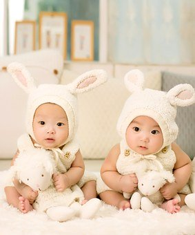

- para mostrar html’s: https://raw.githack.com/

# 4. APRENDIENDO web pages

- Para poner un link interno se hace así `[Guía Docente](./pdfs/Guia-Docente.pdf)` . Los archivos `.txt`, `.pdf` y `.html` sí que se ven, pero los ficheros `.R` y `.Rmd` se descragan